# Reproducible Research course project #1

Robert Gilliland

October 18, 2019

## Load Packagaes

```r
library("ggplot2")
library("dplyr")
library("tidyverse")
```

## Loading and preprocessing the data

```r
activity <- read.csv(file="C:/Users/gillilr/Desktop/coursera/activity/activity.csv")
activity$date<- as.Date(as.character(activity$date, format = "%d/%m/%y/"))
summary(activity)
```

```
##      steps             date               interval
##  Min.   :  0.00   Min.   :2012-10-01   Min.   :   0.0
##  1st Qu.:  0.00   1st Qu.:2012-10-16   1st Qu.: 588.8
##  Median :  0.00   Median :2012-10-31   Median :1177.5
##  Mean   : 37.38   Mean   :2012-10-31   Mean   :1177.5
##  3rd Qu.: 12.00   3rd Qu.:2012-11-15   3rd Qu.:1766.2
##  Max.   :806.00   Max.   :2012-11-30   Max.   :2355.0
##  NA's   :2304
```

# What is mean total number of steps taken per day?

## 1. Calculate the total number of steps taken per day?

```r
stepsperday <- aggregate(steps ~ date, activity, sum, na.rm=TRUE)
```

## 2.If you do not understand the difference between a histogram and a barplot, research the difference between them. Make a histogram of the total number of steps taken each day

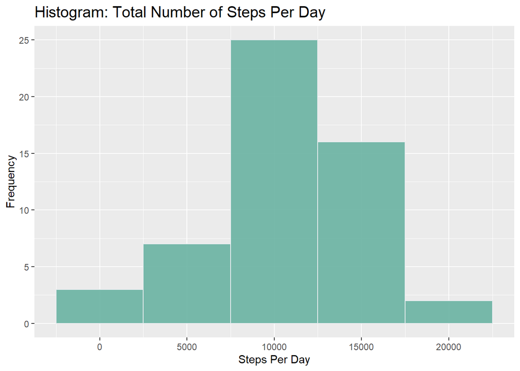

```r
p <- ggplot(stepsperday, aes(x=steps), bin) +
  geom_histogram(binwidth=5000, fill="#69b3a2", color="#e9ecef", alpha=0.9)+
    ggtitle("Histogram: Total Number of Steps Per Day")+ xlab("Steps Per Day") +
  ylab("Frequency") +
    theme(
      plot.title = element_text(size=15)
    )
 p
```

## Calculate and report the mean and median of the total number of steps taken per day

```r
meanstepsperday <- mean(stepsperday$steps)
meanstepsperday
```

```
## [1] 10766.19
```

```r
medianstepsperday <- median(stepsperday$steps)
medianstepsperday
```

```
## [1] 10765
```

# What is the average daily activity pattern?

## 1. Make a time series plot (i.e. type=“l”) of the 5-minute interval (x-axis) and the average number of steps taken, averaged across all days (y-axis)

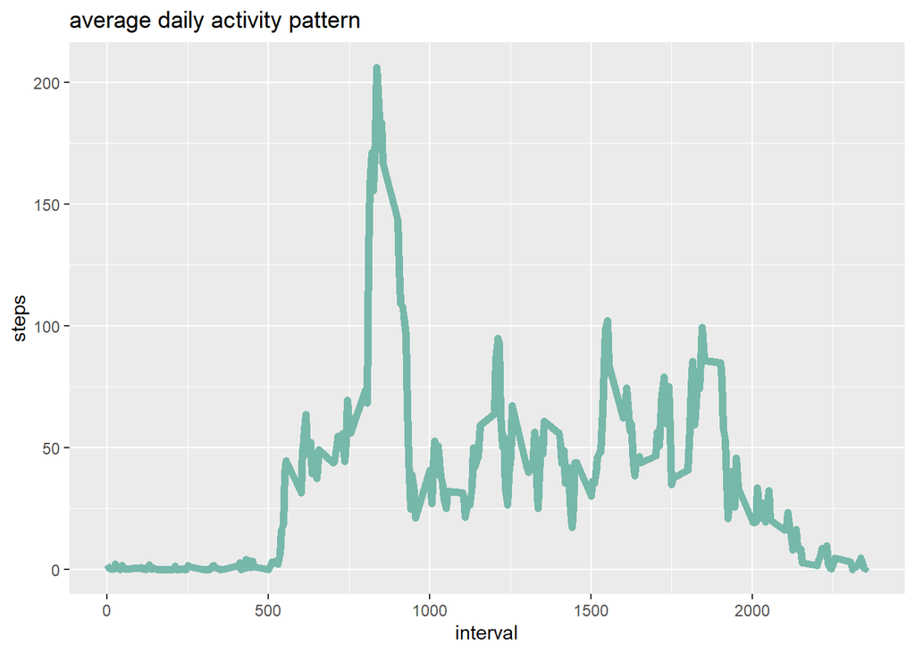

```r
averagedailypattern<-aggregate(steps~interval, data=activity, mean, na.rm=TRUE)

ggplot(averagedailypattern, aes(y=steps, x=interval), type="l") +
 geom_line( color="#69b3a2", size=2, alpha=0.9) +
  ggtitle("average daily activity pattern")
```

## 2. Which 5-minute interval, on average across all the days in the dataset, contains the maximum number of steps?

```r
maxsteps <- averagedailypattern[which.max(averagedailypattern$steps),]$interval
maxsteps
```

```
## [1] 835
```

# Imputing missing values

Note that there are a number of days/intervals where there are missing values (coded as NA). The presence of missing days may introduce bias into some calculations or summaries of the data.

## 1. Calculate and report the total number of missing values in the dataset (i.e. the total number of rows with NAs)

```r
valuesmissings <- sum(is.na(activity$steps))
valuesmissings
```

```
## [1] 2304
```

## 2. Devise a strategy for filling in all of the missing values in the dataset. The strategy does not need to be sophisticated. For example, you could use the mean/median for that day, or the mean for that 5-minute interval, etc.

```r
meanstepsperinterval<-function(interval){
    averagedailypattern[averagedailypattern$interval==interval,]$steps
}
```

## 3. Create a new dataset that is equal to the original dataset but with the missing data filled in.

```r
activitycleaned<-activity
for(i in 1:nrow(activitycleaned)){
    if(is.na(activitycleaned[i,]$steps)){
        activitycleaned[i,]$steps <- meanstepsperinterval(activitycleaned[i,]$interval)
    }
}
```

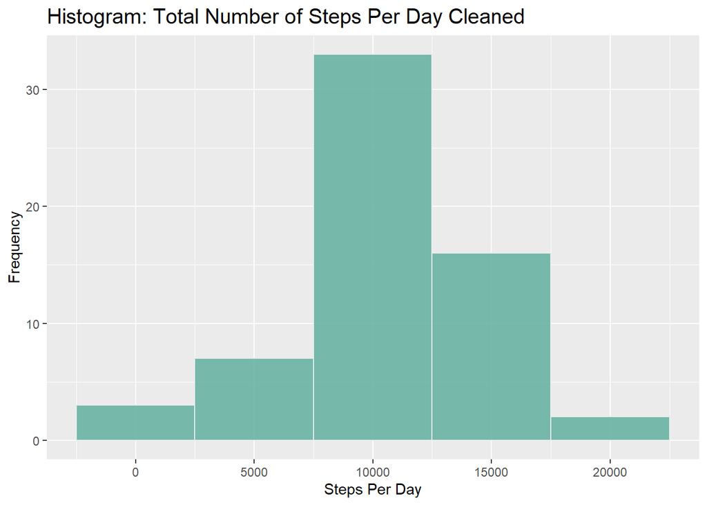

```r
totalstepscleaned <- aggregate(steps ~ date, data=activitycleaned, sum)

p <- ggplot(totalstepscleaned, aes(x=steps), bin) +
  geom_histogram(binwidth=5000, fill="#69b3a2", color="#e9ecef", alpha=0.9)+
    ggtitle("Histogram: Total Number of Steps Per Day Cleaned")+ xlab("Steps Per Day") +
  ylab("Frequency") +
    theme(
      plot.title = element_text(size=15)
    )
 p
```

# Are there differences in activity patterns between weekdays and weekends?

For this part the weekdays() function may be of some help here. Use the dataset with the filled-in missing values for this part.

## 1.Create a new factor variable in the dataset with two levels - “weekday” and “weekend” indicating whether a given date is a weekday or weekend day.

```r
twolevels <- activitycleaned %>% mutate(dayOfWeek = weekdays(date)) %>%
  mutate(Weekend = ifelse(dayOfWeek == "Saturday" | dayOfWeek == "Sunday", "Weekend", "Weekday"))
```

## 2. Make a panel plot containing a time series plot (i.e. type=“l”) of the 5-minute interval (x-axis) and the average number of steps taken, averaged across all weekday days or weekend days (y-axis). See the README file in the GitHub repository to see an example of what this plot should look like using simulated data.

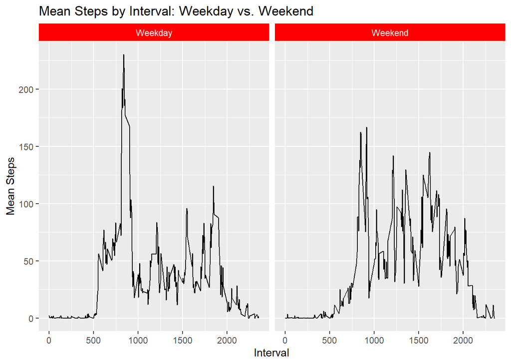

```r
twolevels %>%
  group_by(Weekend, interval) %>% mutate(meanStepsInterval = mean(steps)) %>%
  ggplot(aes(x = interval, y = meanStepsInterval)) + geom_line() +
  facet_wrap(~Weekend) +ggtitle("Mean Steps by Interval: Weekday vs. Weekend") +
  xlab("Interval") + ylab("Mean Steps")+
  theme(strip.background =element_rect(fill="red"))+
  theme(strip.text = element_text(colour = 'white'))
```